# Introduction to R

Stephane Rion, Big Data Partnership

02/08/2015

# Overview

- A brief presentation
- Getting data in R and some useful packages
- Basic functions for data manipulation
- Dataframes
- Simple statistics
- More advanced modelling techniques
- Visualisation
- Useful links and external ressources

# What is R ?

- Statistical programming language descendant of S
- Open source scripting language
- More than 6000 packages !
- Comes as a standalone program or can be run within an IDE (RStudio)

# How to run R scipts

- Run in R console using source: source(‘script.R’)
- From the command line using Rscript: Rscript script.R

# Explore your environment

- Use *dir* to list the files in your current directory
- *getwd / setwd* to change your working folder
- *ls* to list object in curent R session
- *remove* or *rm* to delete a variable
- ? followed by a command name to get help

# Getting data into R (1)

Let’s load a CSV file:

```r
setwd('odi_course_082015')
visits <- read.table('london_visits.csv',row.names=1,sep=',',skip=0)
visits <- read.csv('london_visits.csv',row.names=1)
```

# Getting data into R (2)

```r
install.packages('RODBC')
library(ODBC)
con <- odbcConnect("dbss")
sqlQuery(con, paste("SELECT * FROM School"))
```

But there is plenty of other types of data source accessible: ElasticSearch, MongoDB etc.

# Some basic commands (1)

```r
head(visits,2)
```

```
##           Y2008 Y2009 Y2010 Y2011 Y2012 Y2013 Y2014p
## Argentina  20.1  55.4  52.4  61.1  93.7  93.5   92.5
## Australia 583.7 571.2 624.3 681.3 596.9 687.3  614.4
```

```r
tail(visits,2)
```

```
##         Y2008   Y2009   Y2010   Y2011   Y2012   Y2013  Y2014p
## USA    1907.9  1839.1  1765.6  1842.8  1862.3  1877.9  1979.3
## Total 14753.0 14211.3 14705.5 15289.5 15460.9 16810.8 17404.0
```

# Some basic commands (2)

```r
summary(t(visits)[,1:5])
```

```
##    Argentina       Australia        Austria         Bahrain
##  Min.   :20.10   Min.   :571.2   Min.   :141.7   Min.   :12.10
##  1st Qu.:53.90   1st Qu.:590.3   1st Qu.:144.6   1st Qu.:17.43
##  Median :61.10   Median :614.4   Median :153.0   Median :20.35
##  Mean   :66.96   Mean   :622.7   Mean   :154.8   Mean   :19.18
##  3rd Qu.:93.00   3rd Qu.:652.8   3rd Qu.:165.4   3rd Qu.:22.10
##  Max.   :93.70   Max.   :687.3   Max.   :168.8   Max.   :23.90
##                                                  NA's   :3
##     Belgium
##  Min.   :307.7
##  1st Qu.:378.1
##  Median :470.3
##  Mean   :434.9
##  3rd Qu.:489.5
##  Max.   :530.7
##
```

# R main data types (1)

- Vector

```r
v <- c(1,-1,10,8,-3.5)
print(v)
```

```
## [1]  1.0 -1.0 10.0  8.0 -3.5
```

- Character (string)

```r
s <- 'hello world'
```

- Boolean

```r
(1 == 2)
```

```
## [1] FALSE
```

# R main data types (2)

- List

```r
l <- list(1,2,3,4)
l[[1]]
```

[output not shown]

- Matrix, Dataframes

```r
m <- matrix(c(c(1,2,3),c(4,5,6),c(7,8,9)),nrow=3,ncol=3)
m[1,1:3]
```

```
## [1] 1 4 7
```

We can always convert a matrix to a dataframe:

```r
df <- data.frame(m)
```

# R main data types (3)

```r
myData <- data.frame(time=c("2014-01-23 14:28:21","2014-01-23 14:28:55",
                              "2014-01-23 14:29:02","2014-01-23 14:31:18"),
                      speed=c(2.0,2.2,3.4,5.5))

myData
```

```
##                  time speed
## 1 2014-01-23 14:28:21   2.0
## 2 2014-01-23 14:28:55   2.2
## 3 2014-01-23 14:29:02   3.4
## 4 2014-01-23 14:31:18   5.5
```

# Dataframe manipulation

- Most used object type in R to represent data
- Values in a dataframe can have several types
- Easy to manipulate using vectorized functions

# Let’s have a closer look

```r
data(mtcars)
unique(row.names(mtcars))
```

```
##  [1] "Mazda RX4"           "Mazda RX4 Wag"       "Datsun 710"
##  [4] "Hornet 4 Drive"      "Hornet Sportabout"   "Valiant"
##  [7] "Duster 360"          "Merc 240D"           "Merc 230"
## [10] "Merc 280"            "Merc 280C"           "Merc 450SE"
## [13] "Merc 450SL"          "Merc 450SLC"         "Cadillac Fleetwood"
## [16] "Lincoln Continental" "Chrysler Imperial"   "Fiat 128"
## [19] "Honda Civic"         "Toyota Corolla"      "Toyota Corona"
## [22] "Dodge Challenger"    "AMC Javelin"         "Camaro Z28"
## [25] "Pontiac Firebird"    "Fiat X1-9"           "Porsche 914-2"
## [28] "Lotus Europa"        "Ford Pantera L"      "Ferrari Dino"
## [31] "Maserati Bora"       "Volvo 142E"
```

```r
mtcars[mtcars$mpg<15,]
```

```
##                      mpg cyl disp  hp drat    wt  qsec vs am gear carb
## Duster 360          14.3   8  360 245 3.21 3.570 15.84  0  0    3    4
## Cadillac Fleetwood  10.4   8  472 205 2.93 5.250 17.98  0  0    3    4
## Lincoln Continental 10.4   8  460 215 3.00 5.424 17.82  0  0    3    4
## Chrysler Imperial   14.7   8  440 230 3.23 5.345 17.42  0  0    3    4
## Camaro Z28          13.3   8  350 245 3.73 3.840 15.41  0  0    3    4
```

```r
mtcars[grep('Toy',row.names(mtcars)),]
```

```
##                 mpg cyl  disp hp drat    wt  qsec vs am gear carb
## Toyota Corolla 33.9   4  71.1 65 4.22 1.835 19.90  1  1    4    1
## Toyota Corona  21.5   4 120.1 97 3.70 2.465 20.01  1  0    3    1
```

```r
max(mtcars$cyl)
```

```
## [1] 8
```

# Manipulating dataframes with plyr

```r
library(plyr)
census <- read.csv('odi_course_082015/census.data',sep=',',header = TRUE)
colnames(census) <- c('X,','age','work_class','fnlwgt','education','educ_num', 'marital-status','profession','relationship','race','sex','capital_gain','capital_loss','hours_per_week','country','income')
ddply(census,"race",nrow)
```

```
##                  race    V1
## 1  Amer-Indian-Eskimo   311
## 2  Asian-Pac-Islander  1039
## 3               Black  3124
## 4               Other   271
## 5               White 27816
```

# Now with custom function declaration

```r
library(plyr)
myfunction <- function(x){
df <- summary(x$income)/nrow(x)
return(df)
}
ddply(census,"education",myfunction)
```

```
##        education     <=50K       >50K
## 1           10th 0.9335477 0.06645230
## 2           11th 0.9489362 0.05106383
## 3           12th 0.9237875 0.07621247
## 4        1st-4th 0.9642857 0.03571429
## 5        5th-6th 0.9519520 0.04804805
## 6        7th-8th 0.9380805 0.06191950
## 7            9th 0.9474708 0.05252918
## 8     Assoc-acdm 0.7516401 0.24835989
## 9      Assoc-voc 0.7387844 0.26121563
## 10     Bachelors 0.5852474 0.41475257
## 11     Doctorate 0.2590799 0.74092010
## 12       HS-grad 0.8404914 0.15950862
## 13       Masters 0.4434127 0.55658735
## 14     Preschool 1.0000000 0.00000000
## 15   Prof-school 0.2656250 0.73437500
## 16  Some-college 0.8097655 0.19023454
```

# Built-in statistical functions

- *mean, sd, quantile, cor* etc.

```r
mean(c(1,2,-1,3))
```

```
## [1] 1.25
```

- Statistical tests: z-test, t-test, chi2

Ex of t-test:

```r
x <- c(175, 168, 168, 190, 156, 181, 182, 175, 174, 179)
y <- c(185, 169, 173, 173, 188, 186, 175, 174, 179, 180)
t.test(x,y, var.equal=TRUE)
```

```
##
##  Two Sample t-test
##
## data:  x and y
## t = -0.9474, df = 18, p-value = 0.356
## alternative hypothesis: true difference in means is not equal to 0
## 95 percent confidence interval:
##  -10.93994   4.13994
## sample estimates:
## mean of x mean of y
##     174.8     178.2
```

# Basic Probability Distributions (1)

- Normal, binomial, Chi-Squared and t distribution For every distribution there are four commands. The commands for each distribution are prepended with a letter to indicate the functionality:
- “d” returns the height of the probability density function
- “p” returns the cumulative density function
- “q” returns the inverse cumulative density function (quantiles)
- “r” returns randomly generated numbers

Example for the Normal distribution¶

```r
dnorm(0)
```

```
## [1] 0.3989423
```

```r
v <- c(0,1,2)
dnorm(v)
```

```
## [1] 0.39894228 0.24197072 0.05399097
```

```r
pnorm(0,mean=2,sd=3)
```

```
## [1] 0.2524925
```

```r
qnorm(0.5,mean=2,sd=2)
```

```
## [1] 2
```

```r
rnorm(4)
```

```
## [1]  2.5312999 -1.8203779 -0.8532673  0.5703467
```

# Linear regression

```r
df1 <- as.data.frame(state.x77)
colnames(df1)[4] = "Life.Exp"
colnames(df1)[6] = "HS.Grad"
df1[,9] = df1$Population * 1000 / df1$Area
colnames(df1)[9] = "Density"
cor(df1)
```

```
##             Population     Income   Illiteracy    Life.Exp     Murder
## Population  1.00000000  0.2082276  0.107622373 -0.06805195  0.3436428
## Income      0.20822756  1.0000000 -0.437075186  0.34025534 -0.2300776
## Illiteracy  0.10762237 -0.4370752  1.000000000 -0.58847793  0.7029752
## Life.Exp   -0.06805195  0.3402553 -0.588477926  1.00000000 -0.7808458
## Murder      0.34364275 -0.2300776  0.702975199 -0.78084575  1.0000000
## HS.Grad    -0.09848975  0.6199323 -0.657188609  0.58221620 -0.4879710
## Frost      -0.33215245  0.2262822 -0.671946968  0.26206801 -0.5388834
## Area        0.02254384  0.3633154  0.077261132 -0.10733194  0.2283902
## Density     0.24622789  0.3299683  0.009274348  0.09106176 -0.1850352
##                HS.Grad        Frost        Area      Density
## Population -0.09848975 -0.332152454  0.02254384  0.246227888
## Income      0.61993232  0.226282179  0.36331544  0.329968277
## Illiteracy -0.65718861 -0.671946968  0.07726113  0.009274348
## Life.Exp    0.58221620  0.262068011 -0.10733194  0.091061763
## Murder     -0.48797102 -0.538883437  0.22839021 -0.185035233
## HS.Grad     1.00000000  0.366779702  0.33354187 -0.088367214
## Frost       0.36677970  1.000000000  0.05922910  0.002276734
## Area        0.33354187  0.059229102  1.00000000 -0.341388515
## Density    -0.08836721  0.002276734 -0.34138851  1.000000000
```

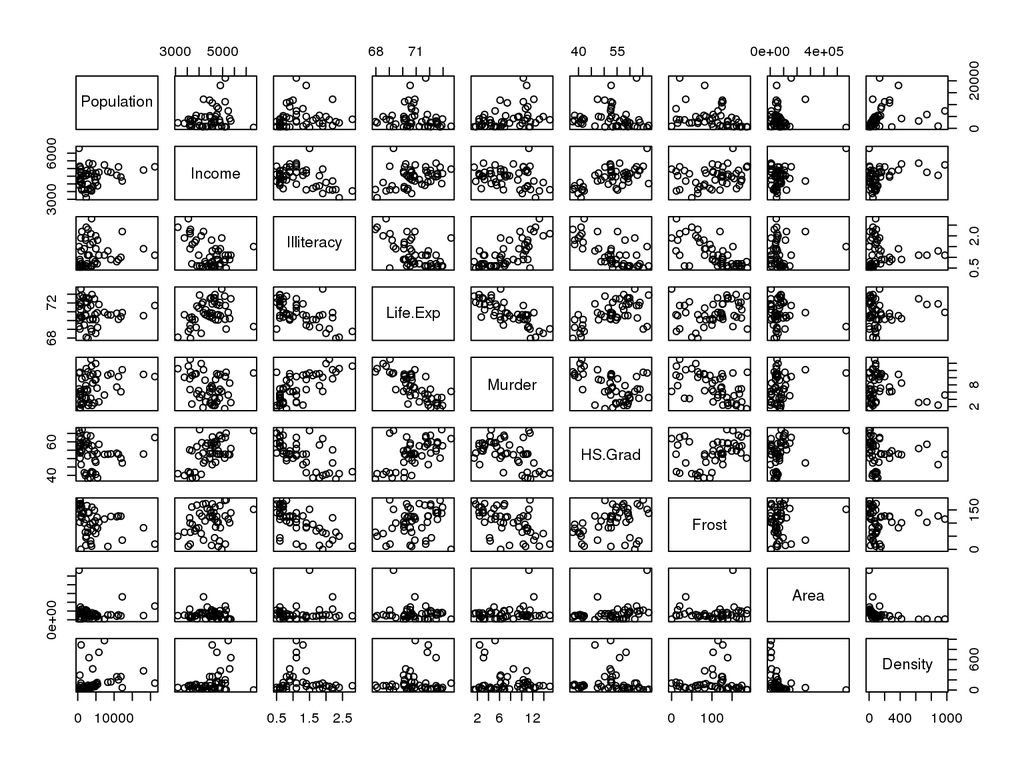

```r
pairs(df1)
```

# The full model

```r
full_model = lm(Life.Exp ~ Population + Income + Illiteracy + Murder + HS.Grad + Frost + Area + Density, data=df1)
summary(full_model)
```

```
##
## Call:
## lm(formula = Life.Exp ~ Population + Income + Illiteracy + Murder +
##     HS.Grad + Frost + Area + Density, data = df1)
##
## Residuals:
##      Min       1Q   Median       3Q      Max
## -1.47514 -0.45887 -0.06352  0.59362  1.21823
##
## Coefficients:
##               Estimate Std. Error t value Pr(>|t|)
## (Intercept)  6.995e+01  1.843e+00  37.956  < 2e-16 ***
## Population   6.480e-05  3.001e-05   2.159   0.0367 *
## Income       2.701e-04  3.087e-04   0.875   0.3867
## Illiteracy   3.029e-01  4.024e-01   0.753   0.4559
## Murder      -3.286e-01  4.941e-02  -6.652 5.12e-08 ***
## HS.Grad      4.291e-02  2.332e-02   1.840   0.0730 .
## Frost       -4.580e-03  3.189e-03  -1.436   0.1585
## Area        -1.558e-06  1.914e-06  -0.814   0.4205
## Density     -1.105e-03  7.312e-04  -1.511   0.1385
## ---
## Signif. codes:  0 '***' 0.001 '**' 0.01 '*' 0.05 '.' 0.1 ' ' 1
##
## Residual standard error: 0.7337 on 41 degrees of freedom
## Multiple R-squared:  0.7501, Adjusted R-squared:  0.7013
## F-statistic: 15.38 on 8 and 41 DF,  p-value: 3.787e-10
```

```r
summary.aov(full_model)
```

```
##             Df Sum Sq Mean Sq F value   Pr(>F)
## Population   1  0.409   0.409   0.760  0.38849
## Income       1 11.595  11.595  21.541 3.53e-05 ***
## Illiteracy   1 19.421  19.421  36.081 4.23e-07 ***
## Murder       1 27.429  27.429  50.959 1.05e-08 ***
## HS.Grad      1  4.099   4.099   7.615  0.00861 **
## Frost        1  2.049   2.049   3.806  0.05792 .
## Area         1  0.001   0.001   0.002  0.96438
## Density      1  1.229   1.229   2.283  0.13847
## Residuals   41 22.068   0.538
## ---
## Signif. codes:  0 '***' 0.001 '**' 0.01 '*' 0.05 '.' 0.1 ' ' 1
```

# Updated model

```r
model2 = update(full_model, .~.-Area)
summary(model2)
```

```
##
## Call:
## lm(formula = Life.Exp ~ Population + Income + Illiteracy + Murder +
##     HS.Grad + Frost + Density, data = df1)
##
## Residuals:
##      Min       1Q   Median       3Q      Max
## -1.50252 -0.40471 -0.06079  0.58682  1.43862
##
## Coefficients:
##               Estimate Std. Error t value Pr(>|t|)
## (Intercept)  7.094e+01  1.378e+00  51.488  < 2e-16 ***
## Population   6.249e-05  2.976e-05   2.100   0.0418 *
## Income       1.485e-04  2.690e-04   0.552   0.5840
## Illiteracy   1.452e-01  3.512e-01   0.413   0.6814
## Murder      -3.319e-01  4.904e-02  -6.768 3.12e-08 ***
## HS.Grad      3.746e-02  2.225e-02   1.684   0.0996 .
## Frost       -5.533e-03  2.955e-03  -1.873   0.0681 .
## Density     -7.995e-04  6.251e-04  -1.279   0.2079
## ---
## Signif. codes:  0 '***' 0.001 '**' 0.01 '*' 0.05 '.' 0.1 ' ' 1
##
## Residual standard error: 0.7307 on 42 degrees of freedom
## Multiple R-squared:  0.746,  Adjusted R-squared:  0.7037
## F-statistic: 17.63 on 7 and 42 DF,  p-value: 1.173e-10
```

```r
model3 = update(model2, .~.-Illiteracy)
summary(model3)
```

```
##
## Call:
## lm(formula = Life.Exp ~ Population + Income + Murder + HS.Grad +
##     Frost + Density, data = df1)
##
## Residuals:
##      Min       1Q   Median       3Q      Max
## -1.49555 -0.41246 -0.05336  0.58399  1.50535
##
## Coefficients:
##               Estimate Std. Error t value Pr(>|t|)
## (Intercept)  7.131e+01  1.042e+00  68.420  < 2e-16 ***
## Population   5.811e-05  2.753e-05   2.110   0.0407 *
## Income       1.324e-04  2.636e-04   0.502   0.6181
## Murder      -3.208e-01  4.054e-02  -7.912 6.32e-10 ***
## HS.Grad      3.499e-02  2.122e-02   1.649   0.1065
## Frost       -6.191e-03  2.465e-03  -2.512   0.0158 *
## Density     -7.324e-04  5.978e-04  -1.225   0.2272
## ---
## Signif. codes:  0 '***' 0.001 '**' 0.01 '*' 0.05 '.' 0.1 ' ' 1
##
## Residual standard error: 0.7236 on 43 degrees of freedom
## Multiple R-squared:  0.745,  Adjusted R-squared:  0.7094
## F-statistic: 20.94 on 6 and 43 DF,  p-value: 2.632e-11
```

```r
model4 = update(model3, .~.-Income)
summary(model4)
```

```
##
## Call:
## lm(formula = Life.Exp ~ Population + Murder + HS.Grad + Frost +
##     Density, data = df1)
##
## Residuals:
##      Min       1Q   Median       3Q      Max
## -1.56877 -0.40951 -0.04554  0.57362  1.54752
##
## Coefficients:
##               Estimate Std. Error t value Pr(>|t|)
## (Intercept)  7.142e+01  1.011e+00  70.665  < 2e-16 ***
## Population   6.083e-05  2.676e-05   2.273  0.02796 *
## Murder      -3.160e-01  3.910e-02  -8.083 3.07e-10 ***
## HS.Grad      4.233e-02  1.525e-02   2.776  0.00805 **
## Frost       -5.999e-03  2.414e-03  -2.485  0.01682 *
## Density     -5.864e-04  5.178e-04  -1.132  0.26360
## ---
## Signif. codes:  0 '***' 0.001 '**' 0.01 '*' 0.05 '.' 0.1 ' ' 1
##
## Residual standard error: 0.7174 on 44 degrees of freedom
## Multiple R-squared:  0.7435, Adjusted R-squared:  0.7144
## F-statistic: 25.51 on 5 and 44 DF,  p-value: 5.524e-12
```

###…And so on… Or we can do:

```r
step(full_model, direction="backward")
```

```
## Start:  AIC=-22.89
## Life.Exp ~ Population + Income + Illiteracy + Murder + HS.Grad +
##     Frost + Area + Density
##
##              Df Sum of Sq    RSS     AIC
## - Illiteracy  1    0.3050 22.373 -24.208
## - Area        1    0.3564 22.425 -24.093
## - Income      1    0.4120 22.480 -23.969
## <none>                    22.068 -22.894
## - Frost       1    1.1102 23.178 -22.440
## - Density     1    1.2288 23.297 -22.185
## - HS.Grad     1    1.8225 23.891 -20.926
## - Population  1    2.5095 24.578 -19.509
## - Murder      1   23.8173 45.886  11.707
##
## Step:  AIC=-24.21
## Life.Exp ~ Population + Income + Murder + HS.Grad + Frost + Area +
##     Density
##
##              Df Sum of Sq    RSS     AIC
## - Area        1    0.1427 22.516 -25.890
## - Income      1    0.2316 22.605 -25.693
## <none>                    22.373 -24.208
## - Density     1    0.9286 23.302 -24.174
## - HS.Grad     1    1.5218 23.895 -22.918
## - Population  1    2.2047 24.578 -21.509
## - Frost       1    3.1324 25.506 -19.656
## - Murder      1   26.7071 49.080  13.072
##
## Step:  AIC=-25.89
## Life.Exp ~ Population + Income + Murder + HS.Grad + Frost + Density
##
##              Df Sum of Sq    RSS     AIC
## - Income      1     0.132 22.648 -27.598
## - Density     1     0.786 23.302 -26.174
## <none>                    22.516 -25.890
## - HS.Grad     1     1.424 23.940 -24.824
## - Population  1     2.332 24.848 -22.962
## - Frost       1     3.304 25.820 -21.043
## - Murder      1    32.779 55.295  17.033
##
## Step:  AIC=-27.6
## Life.Exp ~ Population + Murder + HS.Grad + Frost + Density
##
##              Df Sum of Sq    RSS     AIC
## - Density     1     0.660 23.308 -28.161
## <none>                    22.648 -27.598
## - Population  1     2.659 25.307 -24.046
## - Frost       1     3.179 25.827 -23.030
## - HS.Grad     1     3.966 26.614 -21.529
## - Murder      1    33.626 56.274  15.910
##
## Step:  AIC=-28.16
## Life.Exp ~ Population + Murder + HS.Grad + Frost
##
##              Df Sum of Sq    RSS     AIC
## <none>                    23.308 -28.161
## - Population  1     2.064 25.372 -25.920
## - Frost       1     3.122 26.430 -23.877
## - HS.Grad     1     5.112 28.420 -20.246
## - Murder      1    34.816 58.124  15.528
```

```
##
## Call:
## lm(formula = Life.Exp ~ Population + Murder + HS.Grad + Frost,
##     data = df1)
##
## Coefficients:
## (Intercept)   Population       Murder      HS.Grad        Frost
##   7.103e+01    5.014e-05   -3.001e-01    4.658e-02   -5.943e-03
```

### Comparing linear models (nested)

```r
anova(full_model,model4,test="Chisq")
```

```
## Analysis of Variance Table
##
## Model 1: Life.Exp ~ Population + Income + Illiteracy + Murder + HS.Grad +
##     Frost + Area + Density
## Model 2: Life.Exp ~ Population + Murder + HS.Grad + Frost + Density
##   Res.Df    RSS Df Sum of Sq Pr(>Chi)
## 1     41 22.068
## 2     44 22.648 -3  -0.57966   0.7826
```

### Let’s do a prediction

```r
predict(model4, list(Murder=10.5, HS.Grad=48, Frost=100, Density=35.0, Population=12000))
```

```
##        1
## 70.24107
```

```r
save(model4,file='my_model.rda')
model4 <- load(file='my_model.rda')
```